# Assignment 3

1. Load data into dataframe, inspect with “str” and “summary”, and find each type of variable and explain for categorical variables if it is nominal or ordinal.
2. Convert missing values “?” to NAs

```r
adult <- read.csv("adult.data", header = FALSE, na.strings = " ?", stringsAsFactors = TRUE)
names(adult) <- c("age","workclass","fnlwgt","education","education-num","marital-status","occupation","relationship","race","sex","capital-gain","capital-loss","hours-per-week","native-country","income")

str(adult)
```

```
'data.frame':   32561 obs. of  15 variables:
 $ age           : int  39 50 38 53 28 37 49 52 31 42 ...
 $ workclass     : Factor w/ 8 levels " Federal-gov",..: 7 6 4 4 4 4 4 6 4 4 ...
 $ fnlwgt        : int  77516 83311 215646 234721 338409 284582 160187 209642 45781 159449 ...
 $ education     : Factor w/ 16 levels " 10th"," 11th",..: 10 10 12 2 10 13 7 12 13 10 ...
 $ education-num : int  13 13 9 7 13 14 5 9 14 13 ...
 $ marital-status: Factor w/ 7 levels " Divorced"," Married-AF-spouse",..: 5 3 1 3 3 3 4 3 5 3 ...
 $ occupation    : Factor w/ 14 levels " Adm-clerical",..: 1 4 6 6 10 4 8 4 10 4 ...
 $ relationship  : Factor w/ 6 levels " Husband"," Not-in-family",..: 2 1 2 1 6 6 2 1 2 1 ...
 $ race          : Factor w/ 5 levels " Amer-Indian-Eskimo",..: 5 5 5 3 3 5 3 5 5 5 ...
 $ sex           : Factor w/ 2 levels " Female"," Male": 2 2 2 2 1 1 1 2 1 2 ...
 $ capital-gain  : int  2174 0 0 0 0 0 0 0 14084 5178 ...
 $ capital-loss  : int  0 0 0 0 0 0 0 0 0 0 ...
 $ hours-per-week: int  40 13 40 40 40 40 16 45 50 40 ...
 $ native-country: Factor w/ 41 levels " Cambodia"," Canada",..: 39 39 39 39 5 39 23 39 39 39 ...
 $ income        : Factor w/ 2 levels " <=50K"," >50K": 1 1 1 1 1 1 1 2 2 2 ...
```

```r
summary(adult)
```

```
      age                    workclass         fnlwgt                education     education-num                  marital-status             occupation             relationship                    race            sex
 Min.   :17.00    Private         :22696   Min.   :  12285    HS-grad     :10501   Min.   : 1.00    Divorced             : 4443    Prof-specialty : 4140    Husband       :13193    Amer-Indian-Eskimo:  311    Female:10771
 1st Qu.:28.00    Self-emp-not-inc: 2541   1st Qu.: 117827    Some-college: 7291   1st Qu.: 9.00    Married-AF-spouse    :   23    Craft-repair   : 4099    Not-in-family : 8305    Asian-Pac-Islander: 1039    Male  :21790
 Median :37.00    Local-gov       : 2093   Median : 178356    Bachelors   : 5355   Median :10.00    Married-civ-spouse   :14976    Exec-managerial: 4066    Other-relative:  981    Black             : 3124
 Mean   :38.58    State-gov       : 1298   Mean   : 189778    Masters     : 1723   Mean   :10.08    Married-spouse-absent:  418    Adm-clerical   : 3770    Own-child     : 5068    Other             :  271
 3rd Qu.:48.00    Self-emp-inc    : 1116   3rd Qu.: 237051    Assoc-voc   : 1382   3rd Qu.:12.00    Never-married        :10683    Sales          : 3650    Unmarried     : 3446    White             :27816
 Max.   :90.00   (Other)          :  981   Max.   :1484705    11th        : 1175   Max.   :16.00    Separated            : 1025   (Other)         :10993    Wife          : 1568
                 NA's             : 1836                     (Other)      : 5134                    Widowed              :  993   NA's            : 1843
  capital-gain    capital-loss    hours-per-week         native-country     income
 Min.   :    0   Min.   :   0.0   Min.   : 1.00    United-States:29170    <=50K:24720
 1st Qu.:    0   1st Qu.:   0.0   1st Qu.:40.00    Mexico       :  643    >50K : 7841
 Median :    0   Median :   0.0   Median :40.00    Philippines  :  198
 Mean   : 1078   Mean   :  87.3   Mean   :40.44    Germany      :  137
 3rd Qu.:    0   3rd Qu.:   0.0   3rd Qu.:45.00    Canada       :  121
 Max.   :99999   Max.   :4356.0   Max.   :99.00   (Other)       : 1709
                                                  NA's          :  583
```

age: Numeric Variable

workclass: Categorical Variable, Nominal

fnlwgt: Numeric Variable

education: Categorical Variable, Ordinal

education-num: Numeric Variable

marital-status: Categorical Variable, Nominal

occupation: Categorical Variable, Nominal

relationship: Categorical variable, Nominal

race: Categorical Variable, Nominal

sex: Categorical Variable, Nominal

capital-gain: Numeric Variable

capital-loss: Numeric Variable

hours-per-week: Numeric Variable

native-country: Categorical Variable, Nominal

income: Categorical Variable, Ordinal

3. Set random seed, and split the data to train/test. Use 80% of samples for training and the remaining 20% for testing.

```r
set.seed(5)
adult_sample <- sample(32560, 26049)
adult_train <- adult[adult_sample, ]
adult_test <- adult[-adult_sample,]
```

4. Find which columns in the train and test set have missing values. Replace them with the mean (if numeric) or mode (if categorical). Remember to only input based on the mode or mean of the training data.

```r
calc_mode <- function(x){
  unique_val <- na.omit(unique(x))
  unique_tab <- tabulate(match(x, unique_val))
  unique_val[which.max(unique_tab)]
}

adult_train$workclass[is.na(adult_train$workclass)] <- calc_mode(adult_train$workclass)
adult_train$occupation[is.na(adult_train$occupation)] <- calc_mode(adult_train$occupation)
adult_train$`native-country`[is.na(adult_train$`native-country`)] <- calc_mode(adult_train$`native-country`)


adult_test$workclass[is.na(adult_test$workclass)] <- calc_mode(adult_train$workclass)
adult_test$occupation[is.na(adult_test$occupation)] <- calc_mode(adult_train$occupation)
adult_test$`native-country`[is.na(adult_test$`native-country`)] <- calc_mode(adult_train$`native-country`)
colSums(is.na(adult_train))
```

```
           age      workclass         fnlwgt      education  education-num marital-status     occupation   relationship           race            sex   capital-gain   capital-loss hours-per-week native-country         income
             0              0              0              0              0              0              0              0              0              0              0              0              0              0              0
```

```r
colSums(is.na(adult_test))
```

```
           age      workclass         fnlwgt      education  education-num marital-status     occupation   relationship           race            sex   capital-gain   capital-loss hours-per-week native-country         income
             0              0              0              0              0              0              0              0              0              0              0              0              0              0              0
```

Training set : workclass(categorical), occupation (categorical), and native-country (categorical) have NAs Test set : workclass (categorical), occupation (categorical), and native-country (categorical) have NAs

5. Use plots and statistic tests to find which variables in the dataset are associated with Income. Remove variables not associated with income.

Numeric vs numeric = scatterplot/correlation test Categorical vs Categorical = crosstabs(chi-square test)/ mosaic plot categorical vs numeric = side-by-side boxplots/ 2-sample t-test/ one-way anova

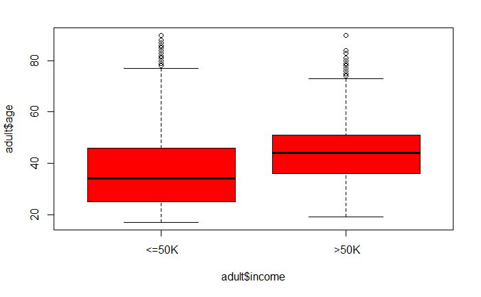

```r
boxplot(adult$age~adult$income, col="red")
```

```r
t.test(adult$age~adult$income, alternative = "two.sided")
```

```
    Welch Two Sample t-test

data:  adult$age by adult$income
t = -50.264, df = 17411, p-value < 2.2e-16
alternative hypothesis: true difference in means between group  <=50K and group  >50K is not equal to 0
95 percent confidence interval:
 -7.757250 -7.174955
sample estimates:
mean in group  <=50K  mean in group  >50K
            36.78374             44.24984
```

There appears to be an association with age and income.

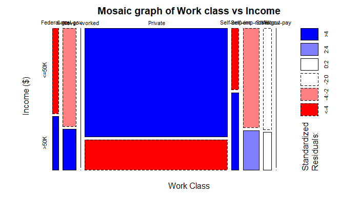

```r
workclass_table <- table(adult$workclass,adult$income)
mosaicplot(workclass_table, xlab ="Work Class", ylab ="Income ($)", main ="Mosaic graph of Work class vs Income", shade=TRUE)
```

```r
chisq.test(workclass_table)
```

```
    Pearson's Chi-squared test

data:  workclass_table
X-squared = 827.72, df = 7, p-value < 2.2e-16
```

There appears to be an association with work class and income.

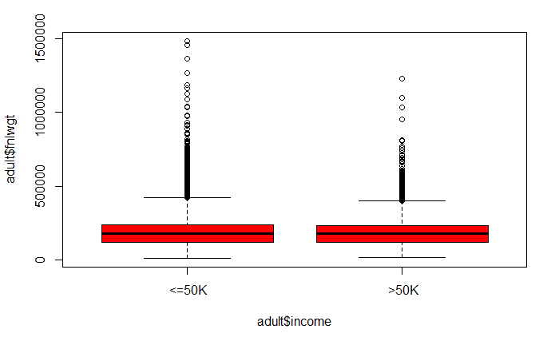

```r
boxplot(adult$fnlwgt~adult$income, col="red")
```

```r
oneway.test(adult$fnlwgt~adult$income, data = adult)
```

```
    One-way analysis of means (not assuming equal variances)

data:  adult$fnlwgt and adult$income
F = 3.0318, num df = 1, denom df = 13615, p-value = 0.08167
```

There does not appear to be an association between fnlwgt and income.

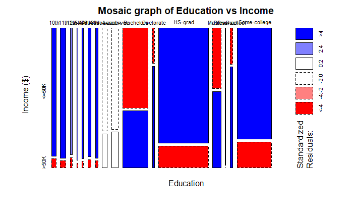

```r
education_table <- table(adult$education,adult$income)
mosaicplot(education_table, xlab ="Education", ylab ="Income ($)", main ="Mosaic graph of Education vs Income", shade=TRUE)
```

```r
chisq.test(education_table)
```

```
    Pearson's Chi-squared test

data:  education_table
X-squared = 4429.7, df = 15, p-value < 2.2e-16
```

There appears to be an association with education and income.

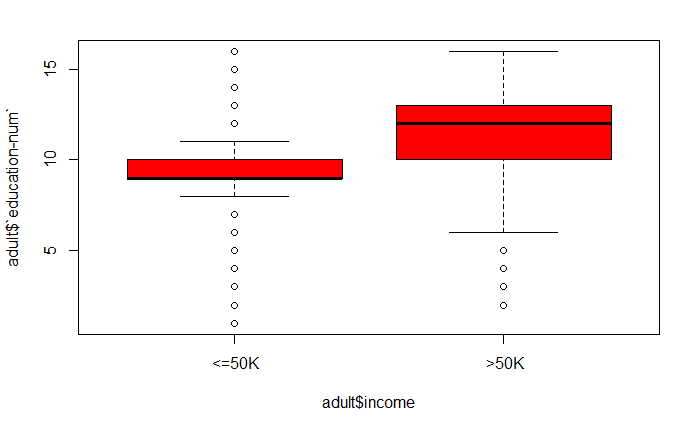

```r
boxplot(adult$`education-num`~adult$income, col="red")
```

```r
oneway.test(adult$`education-num`~adult$income, data = adult)
```

```
    One-way analysis of means (not assuming equal variances)

data:  adult$`education-num` and adult$income
F = 4211.5, num df = 1, denom df = 13421, p-value < 2.2e-16
```

There appears to be an association between education-num and income.

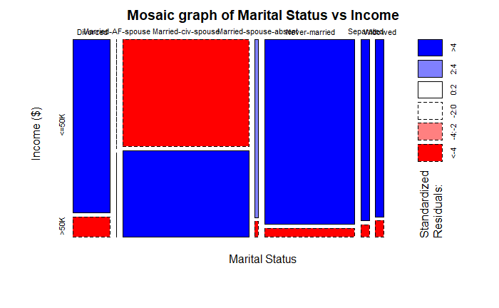

```r
marital_table <- table(adult$`marital-status`,adult$income)
mosaicplot(marital_table, xlab ="Marital Status", ylab ="Income ($)", main ="Mosaic graph of Marital Status vs Income", shade=TRUE)
```

```r
chisq.test(marital_table)
```

```
    Pearson's Chi-squared test

data:  marital_table
X-squared = 6517.7, df = 6, p-value < 2.2e-16
```

There appears to be an association between marital status and income.

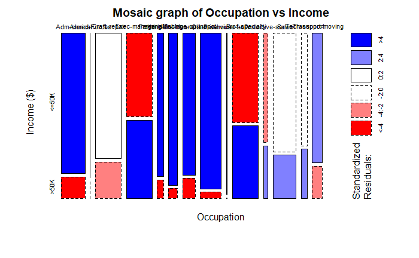

```r
occupation_table <- table(adult$occupation,adult$income)
mosaicplot(occupation_table, xlab ="Occupation", ylab ="Income ($)", main ="Mosaic graph of Occupation vs Income", shade=TRUE)
```

```r
chisq.test(occupation_table)
```

```
    Pearson's Chi-squared test

data:  occupation_table
X-squared = 3744.9, df = 13, p-value < 2.2e-16
```

There appears to be an association between occupation and income.

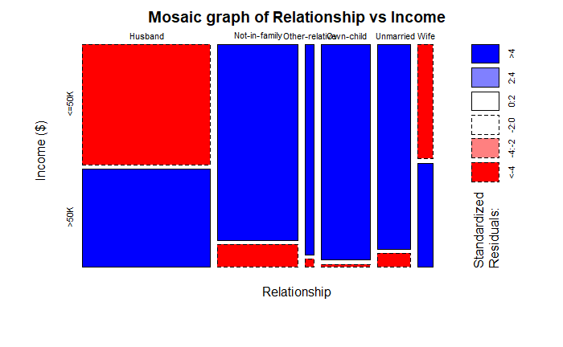

```r
relationship_table <- table(adult$relationship,adult$income)
mosaicplot(relationship_table, xlab ="Relationship", ylab ="Income ($)", main ="Mosaic graph of Relationship vs Income", shade=TRUE)
```

```r
chisq.test(relationship_table)
```

```
    Pearson's Chi-squared test

data:  relationship_table
X-squared = 6699.1, df = 5, p-value < 2.2e-16
```

There appears to be an association between relationship and income.

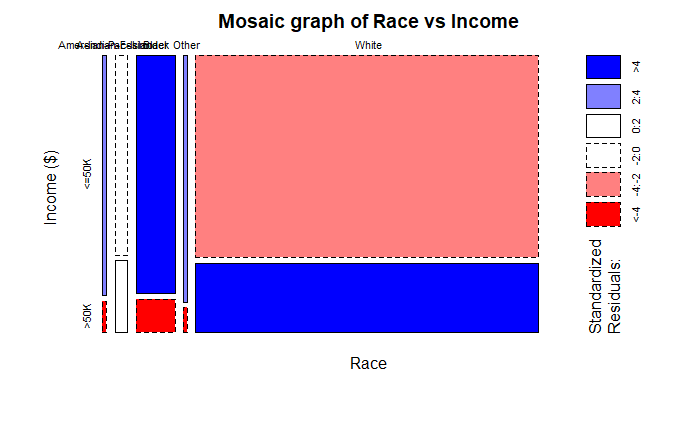

```r
race_table <- table(adult$race,adult$income)
mosaicplot(race_table, xlab ="Race", ylab ="Income ($)", main ="Mosaic graph of Race vs Income", shade=TRUE)
```

```r
chisq.test(race_table)
```

```
    Pearson's Chi-squared test

data:  race_table
X-squared = 330.92, df = 4, p-value < 2.2e-16
```

There appears to be an association between race and income.

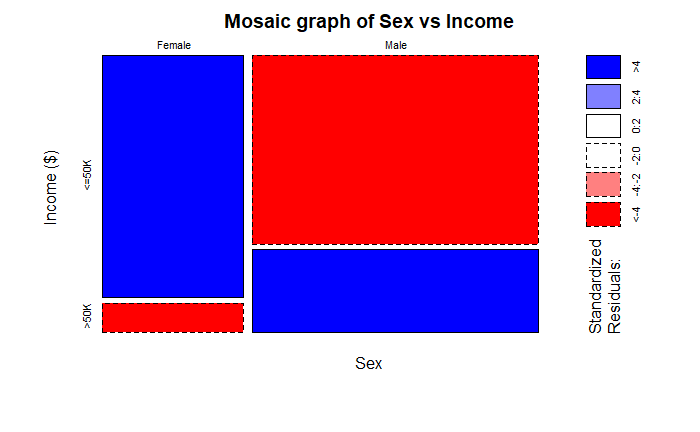

```r
sex_table <- table(adult$sex,adult$income)
mosaicplot(sex_table, xlab ="Sex", ylab ="Income ($)", main ="Mosaic graph of Sex vs Income", shade=TRUE)
```

```r
chisq.test(sex_table)
```

```
    Pearson's Chi-squared test with Yates' continuity correction

data:  sex_table
X-squared = 1517.8, df = 1, p-value < 2.2e-16
```

There appears to be an association between sex and income.

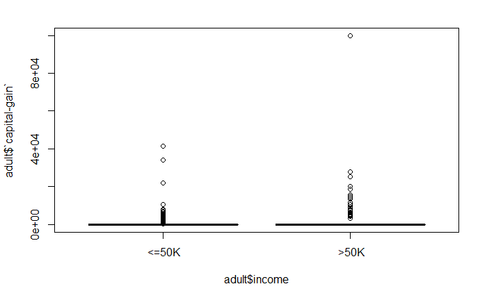

```r
boxplot(adult$`capital-gain`~adult$income, col="red")
```

```r
oneway.test(adult$`capital-gain`~adult$income, data = adult)
```

```
    One-way analysis of means (not assuming equal variances)

data:  adult$`capital-gain` and adult$income
F = 548.8, num df = 1.0, denom df = 7861.7, p-value < 2.2e-16
```

There appears to be an association betweeen capital-gain and income.

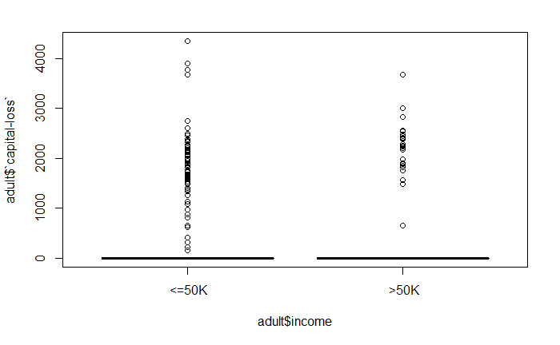

```r
boxplot(adult$`capital-loss`~adult$income, col="red")
```

```r
oneway.test(adult$`capital-loss`~adult$income, data = adult)
```

```
    One-way analysis of means (not assuming equal variances)

data:  adult$`capital-loss` and adult$income
F = 409.6, num df = 1.0, denom df = 9231.1, p-value < 2.2e-16
```

There appears to be an association between capital-loss and income.

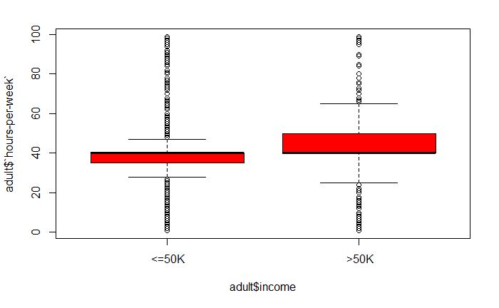

```r
boxplot(adult$`hours-per-week`~adult$income, col="red")
```

```r
oneway.test(adult$`hours-per-week`~adult$income, data = adult)
```

```
    One-way analysis of means (not assuming equal variances)

data:  adult$`hours-per-week` and adult$income
F = 2036.1, num df = 1, denom df = 14570, p-value < 2.2e-16
```

There appears to be an association between hours-per-week and income.

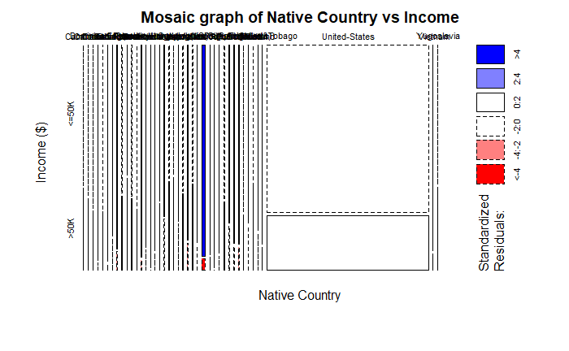

```r
native_country_table <- table(adult$`native-country`,adult$income)
mosaicplot(native_country_table, xlab ="Native Country", ylab ="Income ($)", main ="Mosaic graph of Native Country vs Income", shade=TRUE)
```

```r
chisq.test(native_country_table)
```

```
    Pearson's Chi-squared test

data:  native_country_table
X-squared = 317.09, df = 40, p-value < 2.2e-16
```

There appears to be an association between native country and income.

Remove fnlwgt from the dataset

```r
new_adult_train <- subset(adult_train, select = -fnlwgt)
new_adult_test <- subset(adult_test, select = -fnlwgt)
```

6. train a logistic regression model on the train data and use it to predict “income for test data.

```r
attach(new_adult_test)
logistic_model <- glm(income~., data = new_adult_train, family = "binomial")
summary(logistic_model)
```

```
Call:
glm(formula = income ~ ., family = "binomial", data = new_adult_train)

Deviance Residuals:
    Min       1Q   Median       3Q      Max
-5.0068  -0.5126  -0.1888  -0.0296   3.4670

Coefficients: (1 not defined because of singularities)
                                              Estimate Std. Error z value Pr(>|z|)
(Intercept)                                 -5.467e+00  8.175e-01  -6.688 2.26e-11 ***
age                                          2.212e-02  1.800e-03  12.288  < 2e-16 ***
workclass Local-gov                         -5.810e-01  1.248e-01  -4.655 3.23e-06 ***
workclass Never-worked                      -1.199e+01  2.901e+02  -0.041 0.967028
workclass Private                           -5.030e-01  1.032e-01  -4.873 1.10e-06 ***
workclass Self-emp-inc                      -3.237e-01  1.359e-01  -2.383 0.017186 *
workclass Self-emp-not-inc                  -9.447e-01  1.215e-01  -7.777 7.44e-15 ***
workclass State-gov                         -6.461e-01  1.384e-01  -4.668 3.04e-06 ***
workclass Without-pay                       -1.336e+01  2.200e+02  -0.061 0.951579
education 11th                               1.743e-01  2.409e-01   0.724 0.469280
education 12th                               4.182e-01  3.041e-01   1.375 0.168999
education 1st-4th                           -4.143e-01  5.453e-01  -0.760 0.447344
education 5th-6th                           -1.050e-01  3.573e-01  -0.294 0.768849
education 7th-8th                           -3.298e-01  2.633e-01  -1.253 0.210352
education 9th                               -6.926e-02  2.906e-01  -0.238 0.811625
education Assoc-acdm                         1.405e+00  2.028e-01   6.925 4.36e-12 ***
education Assoc-voc                          1.398e+00  1.953e-01   7.160 8.04e-13 ***
education Bachelors                          2.100e+00  1.819e-01  11.541  < 2e-16 ***
education Doctorate                          3.194e+00  2.418e-01  13.210  < 2e-16 ***
education HS-grad                            8.646e-01  1.781e-01   4.855 1.20e-06 ***
education Masters                            2.492e+00  1.931e-01  12.910  < 2e-16 ***
education Preschool                         -1.792e+01  1.119e+02  -0.160 0.872748
education Prof-school                        2.955e+00  2.272e-01  13.008  < 2e-16 ***
education Some-college                       1.276e+00  1.802e-01   7.081 1.44e-12 ***
`education-num`                                     NA         NA      NA       NA
`marital-status` Married-AF-spouse           2.500e+00  5.986e-01   4.177 2.95e-05 ***
`marital-status` Married-civ-spouse          1.920e+00  2.998e-01   6.403 1.52e-10 ***
`marital-status` Married-spouse-absent      -1.154e-01  2.622e-01  -0.440 0.659717
`marital-status` Never-married              -5.448e-01  9.656e-02  -5.642 1.68e-08 ***
`marital-status` Separated                  -2.276e-01  1.862e-01  -1.223 0.221501
`marital-status` Widowed                     4.395e-03  1.759e-01   0.025 0.980061
```

[output cut: 61 more lines]

```
`native-country` Thailand                   -3.259e+00  1.369e+00  -2.381 0.017269 *
`native-country` Trinadad&Tobago            -1.552e+00  1.122e+00  -1.383 0.166725
`native-country` United-States              -1.561e+00  6.708e-01  -2.327 0.019980 *
`native-country` Vietnam                    -2.733e+00  9.206e-01  -2.969 0.002986 **
`native-country` Yugoslavia                 -1.217e+00  1.022e+00  -1.191 0.233690
---
Signif. codes:  0 ‘***’ 0.001 ‘**’ 0.01 ‘*’ 0.05 ‘.’ 0.1 ‘ ’ 1

(Dispersion parameter for binomial family taken to be 1)

    Null deviance: 28625  on 26048  degrees of freedom
Residual deviance: 16590  on 25953  degrees of freedom
AIC: 16782

Number of Fisher Scoring iterations: 13
```

```r
predictions = predict(logistic_model, new_adult_test, type = "response")
head(predictions)
```

```
          1           6           7           8          13          31
0.167190265 0.820526974 0.001953048 0.363516556 0.006999058 0.075793225
```

```r
predicted.label = factor(ifelse(predictions > 0.5, ">50K", "<=50K"))
actual.label = income
```

7. Create a cross table between predicted and actual labels in the test data and compute total error, precision and recall.

```r
t = table(predicted.label, actual.label)
t
```

```
               actual.label
predicted.label  <=50K  >50K
          <=50K   4557   655
          >50K     329   971
```

```r
error = (t[1,2] + t[2,1])/sum(t)
error
```

```
[1] 0.1511057
```

Precision for <=50k = (TP/ TP + FP) -> (4557 / (4557 + 655)) = .87 Recall for <=50k = (TP / (TP+FN)) -> (4557 / (4557 + 329)) = .93

Precision for >50k = (TP/ TP + FP) -> (971 / (971 + 329)) = .74 Recall for >50k = (TP / (TP + FN)) -> (971/ (971 + 655)) = .59

8. Target “income” is unbalanced, divide training data to 2 sets (adults making <=50K and adults who make >50K). Take a sample size m from <=50K set. Combine above sample with >50K set. Re-train logistic regression model on the balanced training data and eval the test data. Compare total error, precision and recall for both classes with the previous model, which model is better at predicting each class?

```r
library(dplyr)
split_greater_train <- subset(new_adult_train, income %in% c(" >50K"))
split_less_train <- subset(new_adult_train, income %in% c(" <=50K"))

split_less_train_sample <- sample_n(split_less_train, 6215)
balanced_train <- rbind(split_greater_train,split_less_train_sample, deparse.level = 1)

logistic_model_balanced <- glm(income~., data = balanced_train, family = "binomial")
balance_predictions = predict(logistic_model_balanced, new_adult_test, type = "response")
head(balance_predictions)
```

```
          1           6           7           8          13          31
0.378255577 0.937921724 0.004090184 0.659257150 0.018507225 0.216953966
```

```r
predicted_balance.label = factor(ifelse(balance_predictions > 0.5, ">50K", "<=50K"))
actual_balance.label = income



t_bal = table(predicted_balance.label, actual_balance.label)
t_bal
```

```
                       actual_balance.label
predicted_balance.label  <=50K  >50K
                  <=50K   3918   247
                  >50K     968  1379
```

```r
error_bal = (t_bal[1,2] + t_bal[2,1])/sum(t_bal)
error_bal
```

```
[1] 0.1865786
```

The total error is more on balanced model compared to the previous model.

Precision for <=50K = (3918 / (3918 + 247)) = .94 Recall for <=50K = (3918 / (3918 + 968)) = .80

Precision for >50K = (1379 / (1379 + 968)) = .59 Recall for >50K = (1379 / (1379 + 247)) = .85

The balanced model had a better score for precision for <=50K and recall for >50K, while the previous model had a better score for precision for >50K and recall for <=50K.

9. Train the data with C5.0 decision tree model and compare logistic regression model with boosted C5.0 model.

```r
library(C50)
adult_train_boost <- C5.0(new_adult_train[-14], new_adult_train$income, trials = 30)

adult_train_boost_pred <- predict(adult_train_boost, new_adult_test)

library(gmodels)
CrossTable(new_adult_test$income, adult_train_boost_pred, prop.chisq = FALSE, prop.c = FALSE, prop.r = FALSE, dnn = c('actual income', 'predicted income'))
```

```
   Cell Contents
|-------------------------|
|                       N |
|         N / Table Total |
|-------------------------|


Total Observations in Table:  6512


              | predicted income
actual income |     <=50K |      >50K | Row Total |
--------------|-----------|-----------|-----------|
        <=50K |      4593 |       293 |      4886 |
              |     0.705 |     0.045 |           |
--------------|-----------|-----------|-----------|
         >50K |       568 |      1058 |      1626 |
              |     0.087 |     0.162 |           |
--------------|-----------|-----------|-----------|
 Column Total |      5161 |      1351 |      6512 |
--------------|-----------|-----------|-----------|
```

Total error -> (568 + 293)/ (6512) = .13

With the C5.0 decision tree model, the boosted tree model performed better than the linear regression model for the unbalanced data set in total error, precision for <=50K,and recall for >50K.

```r
balance_train_boost <- C5.0(balanced_train[-14], balanced_train$income, trials = 30)

balance_train_boost_pred <- predict(balance_train_boost, new_adult_test)

library(gmodels)
CrossTable(new_adult_test$income, balance_train_boost_pred, prop.chisq = FALSE, prop.c = FALSE, prop.r = FALSE, dnn = c('actual income', 'predicted income'))
```

```
   Cell Contents
|-------------------------|
|                       N |
|         N / Table Total |
|-------------------------|


Total Observations in Table:  6512


              | predicted income
actual income |     <=50K |      >50K | Row Total |
--------------|-----------|-----------|-----------|
        <=50K |      4028 |       858 |      4886 |
              |     0.619 |     0.132 |           |
--------------|-----------|-----------|-----------|
         >50K |       221 |      1405 |      1626 |
              |     0.034 |     0.216 |           |
--------------|-----------|-----------|-----------|
 Column Total |      4249 |      2263 |      6512 |
--------------|-----------|-----------|-----------|
```

Total error -> (221 + 858) / 6512 = .17

Problem 2:

10. Read dataset into a dataframe, ensuring correct delimiter and set the “sep” option accordingly.

```r
student <- read.csv("student-mat.csv", sep = ";", stringsAsFactors = FALSE)
```

11. Explore dataset

```r
str(student)
```

```
'data.frame':   395 obs. of  33 variables:
 $ school    : chr  "GP" "GP" "GP" "GP" ...
 $ sex       : chr  "F" "F" "F" "F" ...
 $ age       : int  18 17 15 15 16 16 16 17 15 15 ...
 $ address   : chr  "U" "U" "U" "U" ...
 $ famsize   : chr  "GT3" "GT3" "LE3" "GT3" ...
 $ Pstatus   : chr  "A" "T" "T" "T" ...
 $ Medu      : int  4 1 1 4 3 4 2 4 3 3 ...
 $ Fedu      : int  4 1 1 2 3 3 2 4 2 4 ...
 $ Mjob      : chr  "at_home" "at_home" "at_home" "health" ...
 $ Fjob      : chr  "teacher" "other" "other" "services" ...
 $ reason    : chr  "course" "course" "other" "home" ...
 $ guardian  : chr  "mother" "father" "mother" "mother" ...
 $ traveltime: int  2 1 1 1 1 1 1 2 1 1 ...
 $ studytime : int  2 2 2 3 2 2 2 2 2 2 ...
```

[output cut: 19 more lines]

```r
summary(student)
```

```
    school              sex                 age         address            famsize            Pstatus               Medu            Fedu           Mjob               Fjob              reason            guardian
 Length:395         Length:395         Min.   :15.0   Length:395         Length:395         Length:395         Min.   :0.000   Min.   :0.000   Length:395         Length:395         Length:395         Length:395
 Class :character   Class :character   1st Qu.:16.0   Class :character   Class :character   Class :character   1st Qu.:2.000   1st Qu.:2.000   Class :character   Class :character   Class :character   Class :character
 Mode  :character   Mode  :character   Median :17.0   Mode  :character   Mode  :character   Mode  :character   Median :3.000   Median :2.000   Mode  :character   Mode  :character   Mode  :character   Mode  :character
                                       Mean   :16.7                                                            Mean   :2.749   Mean   :2.522
                                       3rd Qu.:18.0                                                            3rd Qu.:4.000   3rd Qu.:3.000
                                       Max.   :22.0                                                            Max.   :4.000   Max.   :4.000
   traveltime      studytime        failures       schoolsup            famsup              paid            activities          nursery             higher            internet           romantic             famrel
 Min.   :1.000   Min.   :1.000   Min.   :0.0000   Length:395         Length:395         Length:395         Length:395         Length:395         Length:395         Length:395         Length:395         Min.   :1.000
 1st Qu.:1.000   1st Qu.:1.000   1st Qu.:0.0000   Class :character   Class :character   Class :character   Class :character   Class :character   Class :character   Class :character   Class :character   1st Qu.:4.000
 Median :1.000   Median :2.000   Median :0.0000   Mode  :character   Mode  :character   Mode  :character   Mode  :character   Mode  :character   Mode  :character   Mode  :character   Mode  :character   Median :4.000
 Mean   :1.448   Mean   :2.035   Mean   :0.3342                                                                                                                                                           Mean   :3.944
 3rd Qu.:2.000   3rd Qu.:2.000   3rd Qu.:0.0000                                                                                                                                                           3rd Qu.:5.000
 Max.   :4.000   Max.   :4.000   Max.   :3.0000                                                                                                                                                           Max.   :5.000
    freetime         goout            Dalc            Walc           health         absences            G1              G2              G3
 Min.   :1.000   Min.   :1.000   Min.   :1.000   Min.   :1.000   Min.   :1.000   Min.   : 0.000   Min.   : 3.00   Min.   : 0.00   Min.   : 0.00
 1st Qu.:3.000   1st Qu.:2.000   1st Qu.:1.000   1st Qu.:1.000   1st Qu.:3.000   1st Qu.: 0.000   1st Qu.: 8.00   1st Qu.: 9.00   1st Qu.: 8.00
 Median :3.000   Median :3.000   Median :1.000   Median :2.000   Median :4.000   Median : 4.000   Median :11.00   Median :11.00   Median :11.00
 Mean   :3.235   Mean   :3.109   Mean   :1.481   Mean   :2.291   Mean   :3.554   Mean   : 5.709   Mean   :10.91   Mean   :10.71   Mean   :10.42
 3rd Qu.:4.000   3rd Qu.:4.000   3rd Qu.:2.000   3rd Qu.:3.000   3rd Qu.:5.000   3rd Qu.: 8.000   3rd Qu.:13.00   3rd Qu.:13.00   3rd Qu.:14.00
 Max.   :5.000   Max.   :5.000   Max.   :5.000   Max.   :5.000   Max.   :5.000   Max.   :75.000   Max.   :19.00   Max.   :19.00   Max.   :20.00
```

```r
colSums(is.na(student))
```

```
    school        sex        age    address    famsize    Pstatus       Medu       Fedu       Mjob       Fjob     reason   guardian traveltime  studytime   failures  schoolsup     famsup       paid activities    nursery
         0          0          0          0          0          0          0          0          0          0          0          0          0          0          0          0          0          0          0          0
    higher   internet   romantic     famrel   freetime      goout       Dalc       Walc     health   absences         G1         G2         G3
         0          0          0          0          0          0          0          0          0          0          0          0          0
```

11.a There are no missing values in the dataset.

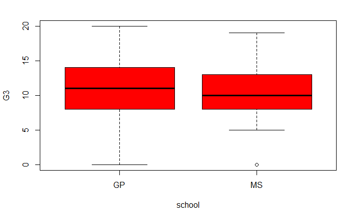

```r
attach(student)
boxplot(G3~school, col="red")
```

```r
oneway.test(G3~school, data = student)
```

```
    One-way analysis of means (not assuming equal variances)

data:  G3 and school
F = 0.91307, num df = 1.000, denom df = 60.054, p-value = 0.3431
```

There does not appear to be an association with school and G3.

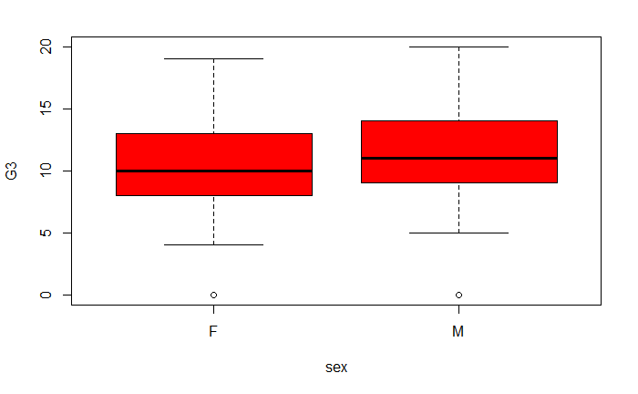

```r
boxplot(G3~sex, col="red")
```

```r
oneway.test(G3~sex, data = student)
```

```
    One-way analysis of means (not assuming equal variances)

data:  G3 and sex
F = 4.2645, num df = 1.00, denom df = 390.57, p-value = 0.03958
```

There appears to be an association with G3 and sex.

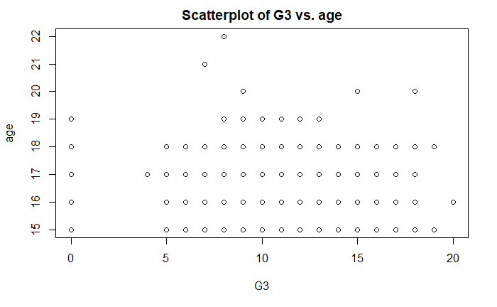

```r
plot(x = G3, y = age, main = "Scatterplot of G3 vs. age", xlab = "G3", ylab = "age")
```

```r
cor.test(G3, age)
```

```
    Pearson's product-moment correlation

data:  G3 and age
t = -3.2458, df = 393, p-value = 0.001271
alternative hypothesis: true correlation is not equal to 0
95 percent confidence interval:
 -0.25616635 -0.06392762
sample estimates:
       cor
-0.1615794
```

There appears to be an association with age and G3.

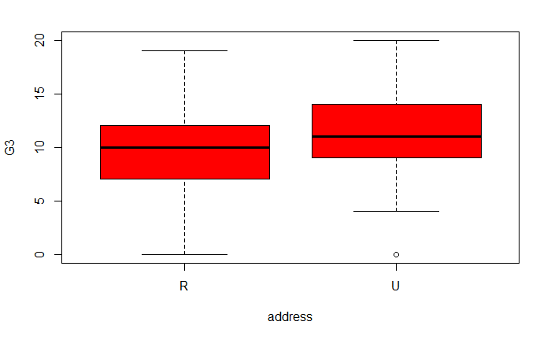

```r
boxplot(G3~address, col="red")
```

```r
oneway.test(G3~address, data = student)
```

```
    One-way analysis of means (not assuming equal variances)

data:  G3 and address
F = 4.4527, num df = 1.00, denom df = 140.91, p-value = 0.03661
```

There appears to be an association with address and G3.

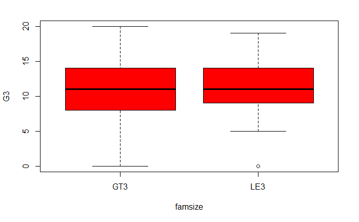

```r
boxplot(G3~famsize, col="red")
```

```r
oneway.test(G3~famsize, data = student)
```

```
    One-way analysis of means (not assuming equal variances)

data:  G3 and famsize
F = 2.8706, num df = 1.00, denom df = 231.57, p-value = 0.09155
```

There does not appear to be an association with famsize and G3.

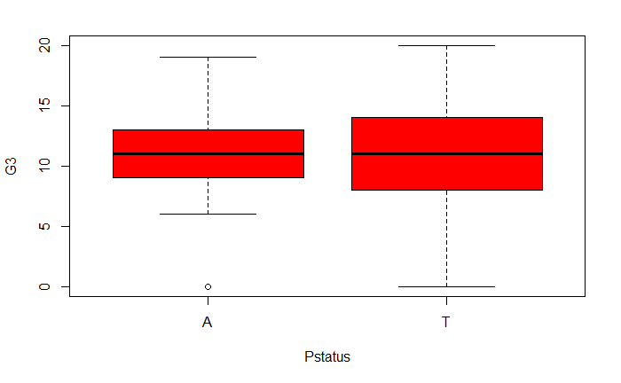

```r
boxplot(G3~Pstatus, col="red")
```

```r
oneway.test(G3~Pstatus, data = student)
```

```
    One-way analysis of means (not assuming equal variances)

data:  G3 and Pstatus
F = 1.4876, num df = 1.000, denom df = 51.312, p-value = 0.2282
```

There does not appear to be an association with Pstatus and G3.

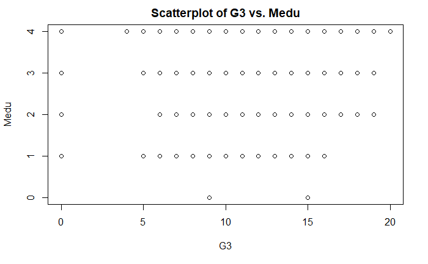

```r
plot(x = G3, y = Medu, main = "Scatterplot of G3 vs. Medu", xlab = "G3", ylab = "Medu")
```

```r
cor.test(G3, Medu)
```

```
    Pearson's product-moment correlation

data:  G3 and Medu
t = 4.41, df = 393, p-value = 1.336e-05
alternative hypothesis: true correlation is not equal to 0
95 percent confidence interval:
 0.1210705 0.3091937
sample estimates:
      cor
0.2171475
```

There appears to be an association between G3 and Medu.

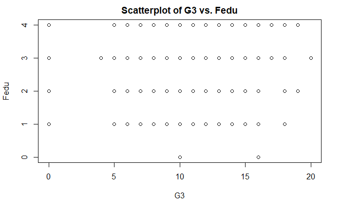

```r
plot(x = G3, y = Fedu, main = "Scatterplot of G3 vs. Fedu", xlab = "G3", ylab = "Fedu")
```

```r
cor.test(G3, Fedu)
```

```
    Pearson's product-moment correlation

data:  G3 and Fedu
t = 3.0581, df = 393, p-value = 0.00238
alternative hypothesis: true correlation is not equal to 0
95 percent confidence interval:
 0.05460737 0.24740621
sample estimates:
      cor
0.1524569
```

There appears to be an association between G3 and Fedu

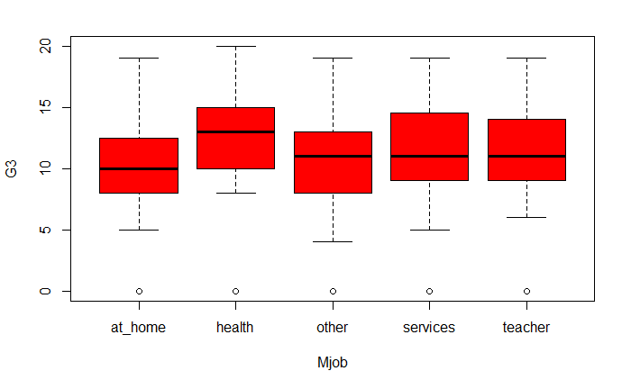

```r
boxplot(G3~Mjob, col="red")
```

```r
oneway.test(G3~Mjob, data = student)
```

```
    One-way analysis of means (not assuming equal variances)

data:  G3 and Mjob
F = 3.7885, num df = 4.0, denom df = 136.4, p-value = 0.005927
```

There appears to be an association between G3 and Mjob.

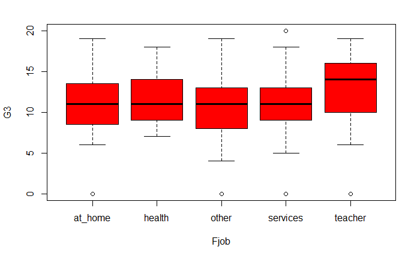

```r
boxplot(G3~Fjob, col="red")
```

```r
oneway.test(G3~Fjob, data = student)
```

```
    One-way analysis of means (not assuming equal variances)

data:  G3 and Fjob
F = 1.3092, num df = 4.000, denom df = 58.911, p-value = 0.2771
```

There does not seem to be an association between Fjob and G3.

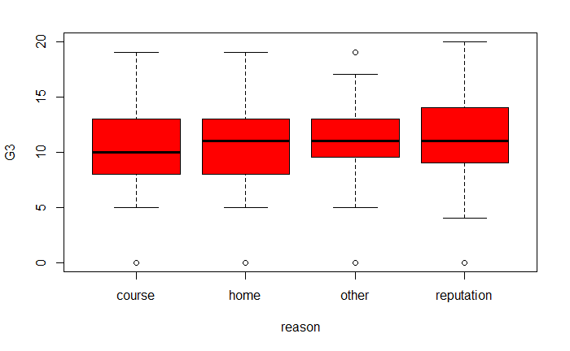

```r
boxplot(G3~reason, col="red")
```

```r
oneway.test(G3~reason, data = student)
```

```
    One-way analysis of means (not assuming equal variances)

data:  G3 and reason
F = 2.1899, num df = 3.00, denom df = 144.09, p-value = 0.0918
```

There does not seem to be an association between reason and G3.

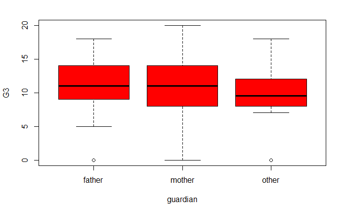

```r
boxplot(G3~guardian, col="red")
```

```r
oneway.test(G3~guardian, data = student)
```

```
    One-way analysis of means (not assuming equal variances)

data:  G3 and guardian
F = 1.5167, num df = 2.000, denom df = 77.625, p-value = 0.2259
```

There does not seem to be an association between guardian and G3.

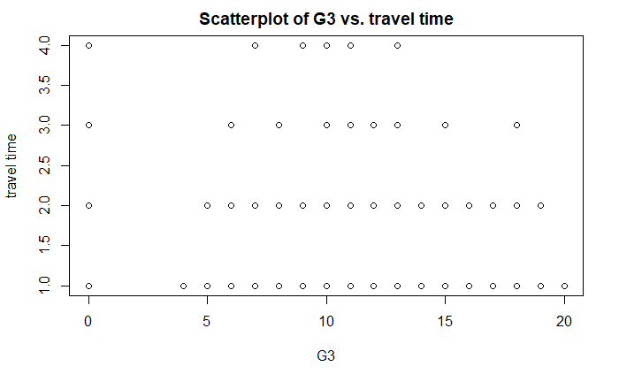

```r
plot(x = G3, y = traveltime, main = "Scatterplot of G3 vs. travel time", xlab = "G3", ylab = "travel time")
```

```r
cor.test(G3, traveltime)
```

```
    Pearson's product-moment correlation

data:  G3 and traveltime
t = -2.3383, df = 393, p-value = 0.01987
alternative hypothesis: true correlation is not equal to 0
95 percent confidence interval:
 -0.21334710 -0.01868702
sample estimates:
       cor
-0.1171421
```

There appears to be an association between traveltime and G3.

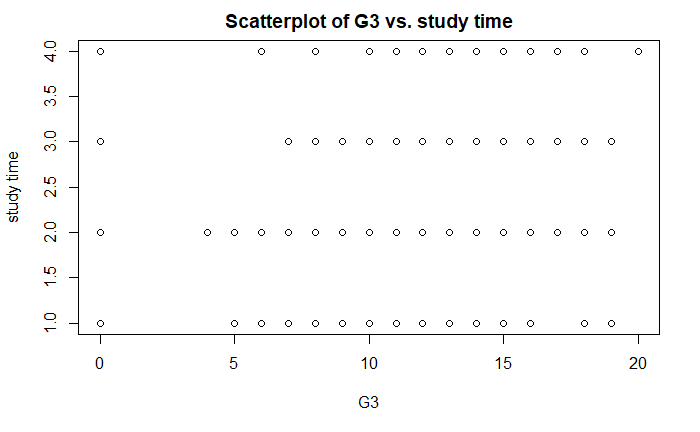

```r
plot(x = G3, y = studytime, main = "Scatterplot of G3 vs. study time", xlab = "G3", ylab = "study time")
```

```r
cor.test(G3, studytime)
```

```
    Pearson's product-moment correlation

data:  G3 and studytime
t = 1.9485, df = 393, p-value = 0.05206
alternative hypothesis: true correlation is not equal to 0
95 percent confidence interval:
 -0.0008596347  0.1946123247
sample estimates:
       cor
0.09781969
```

There does not appear to be an association between studytime and G3.

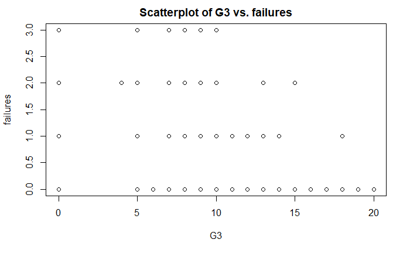

```r
plot(x = G3, y = failures, main = "Scatterplot of G3 vs. failures", xlab = "G3", ylab = "failures")
```

```r
cor.test(G3, failures)
```

```
    Pearson's product-moment correlation

data:  G3 and failures
t = -7.6597, df = 393, p-value = 1.466e-13
alternative hypothesis: true correlation is not equal to 0
95 percent confidence interval:
 -0.4433204 -0.2713954
sample estimates:
       cor
-0.3604149
```

There appears to be an association between failures and G3.

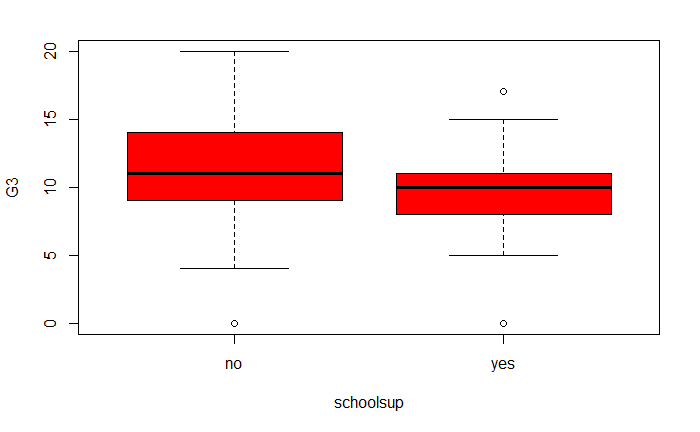

```r
boxplot(G3~schoolsup, col="red")
```

```r
oneway.test(G3~schoolsup, data = student)
```

```
    One-way analysis of means (not assuming equal variances)

data:  G3 and schoolsup
F = 5.6191, num df = 1.000, denom df = 97.126, p-value = 0.01974
```

There appears to be an association between schoolsup and G3.

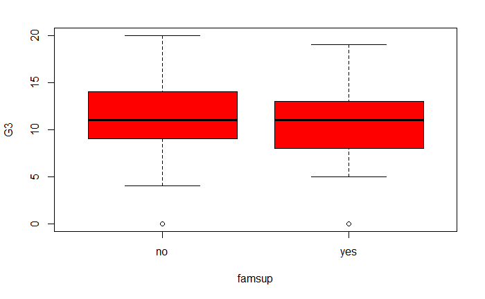

```r
boxplot(G3~famsup, col="red")
```

```r
oneway.test(G3~famsup, data = student)
```

```
    One-way analysis of means (not assuming equal variances)

data:  G3 and famsup
F = 0.59843, num df = 1.00, denom df = 318.91, p-value = 0.4398
```

There does not seem to be an association between famsup and G3.

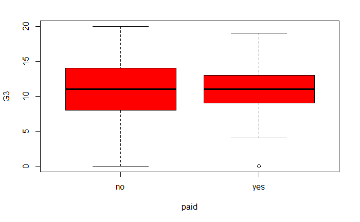

```r
 boxplot(G3~paid, col="red")
```

```r
oneway.test(G3~paid, data = student)
```

```
    One-way analysis of means (not assuming equal variances)

data:  G3 and paid
F = 4.3392, num df = 1.00, denom df = 386.36, p-value = 0.0379
```

There appears to be an association between paid and G3.

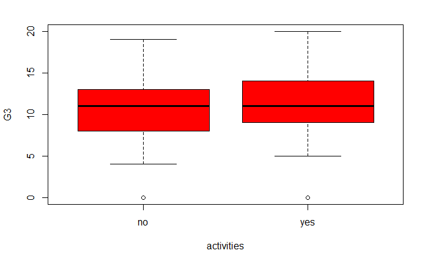

```r
boxplot(G3~activities, col="red")
```

```r
oneway.test(G3~activities, data = student)
```

```
    One-way analysis of means (not assuming equal variances)

data:  G3 and activities
F = 0.10204, num df = 1.00, denom df = 392.98, p-value = 0.7496
```

There does not seem to be an association between activities and G3.

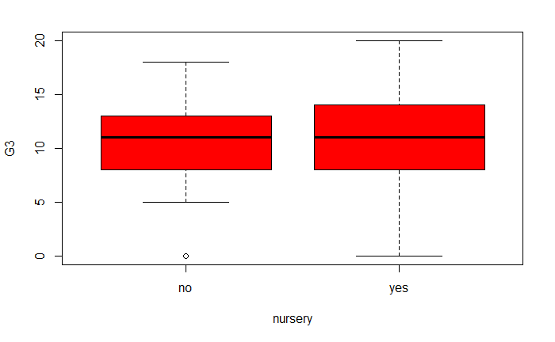

```r
boxplot(G3~nursery, col="red")
```

```r
oneway.test(G3~nursery, data = student)
```

```
    One-way analysis of means (not assuming equal variances)

data:  G3 and nursery
F = 1.0549, num df = 1.00, denom df = 125.02, p-value = 0.3064
```

There does not appear to be an association between nursery and G3.

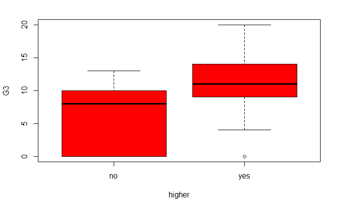

```r
boxplot(G3~higher, col="red")
```

```r
oneway.test(G3~higher, data = student)
```

```
    One-way analysis of means (not assuming equal variances)

data:  G3 and higher
F = 11.884, num df = 1.000, denom df = 20.792, p-value = 0.00244
```

There appears to be an association between higher and G3.

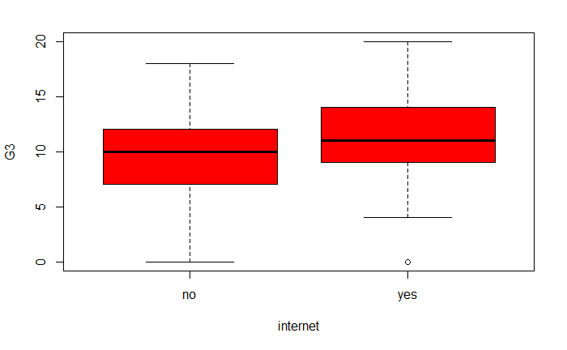

```r
boxplot(G3~internet, col="red")
```

```r
oneway.test(G3~internet, data = student)
```

```
    One-way analysis of means (not assuming equal variances)

data:  G3 and internet
F = 3.9579, num df = 1.000, denom df = 94.219, p-value = 0.04955
```

There appears to be an association between internet and G3.

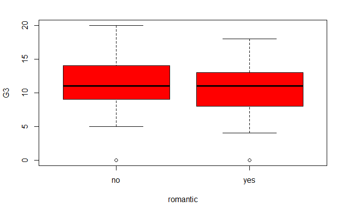

```r
boxplot(G3~romantic, col="red")
```

```r
oneway.test(G3~romantic, data = student)
```

```
    One-way analysis of means (not assuming equal variances)

data:  G3 and romantic
F = 6.3112, num df = 1.00, denom df = 240.07, p-value = 0.01266
```

There appears to be an association between romantic and G3.

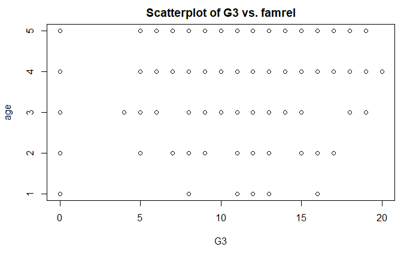

```r
plot(x = G3, y = famrel, main = "Scatterplot of G3 vs. famrel", xlab = "G3", ylab = "age")
```

```r
cor.test(G3, famrel)
```

```
    Pearson's product-moment correlation

data:  G3 and famrel
t = 1.0196, df = 393, p-value = 0.3086
alternative hypothesis: true correlation is not equal to 0
95 percent confidence interval:
 -0.04754858  0.14927790
sample estimates:
       cor
0.05136343
```

There does not seem to be an association between famrel and G3.

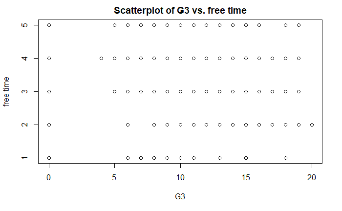

```r
plot(x = G3, y = freetime, main = "Scatterplot of G3 vs. free time", xlab = "G3", ylab = "free time")
```

```r
cor.test(G3, freetime)
```

```
    Pearson's product-moment correlation

data:  G3 and freetime
t = 0.22417, df = 393, p-value = 0.8227
alternative hypothesis: true correlation is not equal to 0
95 percent confidence interval:
 -0.08746137  0.10985570
sample estimates:
       cor
0.01130724
```

There does not seem to be an association between freetime and G3.

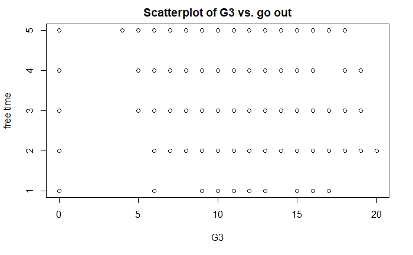

```r
plot(x = G3, y = goout, main = "Scatterplot of G3 vs. go out", xlab = "G3", ylab = "free time")
```

```r
cor.test(G3, goout)
```

```
    Pearson's product-moment correlation

data:  G3 and goout
t = -2.656, df = 393, p-value = 0.008229
alternative hypothesis: true correlation is not equal to 0
95 percent confidence interval:
 -0.22846895 -0.03457345
sample estimates:
       cor
-0.1327915
```

There appears to be an association between goout and G3.

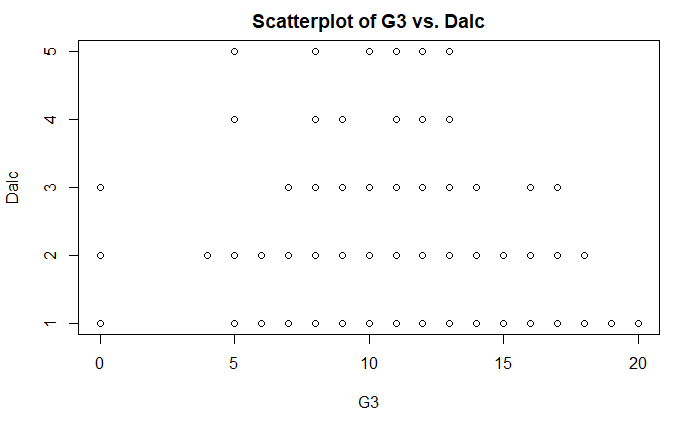

```r
plot(x = G3, y = Dalc, main = "Scatterplot of G3 vs. Dalc", xlab = "G3", ylab = "Dalc")
```

```r
cor.test(G3, age)
```

[output not shown]

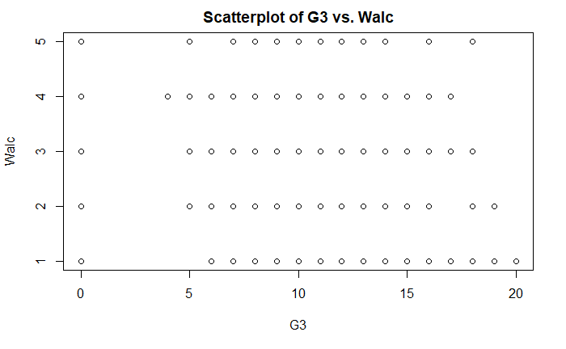

```r
plot(x = G3, y = Walc, main = "Scatterplot of G3 vs. Walc", xlab = "G3", ylab = "Walc")
```

```r
cor.test(G3, Walc)
```

```
    Pearson's product-moment correlation

data:  G3 and Walc
t = -1.031, df = 393, p-value = 0.3032
alternative hypothesis: true correlation is not equal to 0
95 percent confidence interval:
 -0.14984242  0.04697243
sample estimates:
        cor
-0.05193932
```

There does not seem to be an association between Walc and G3.

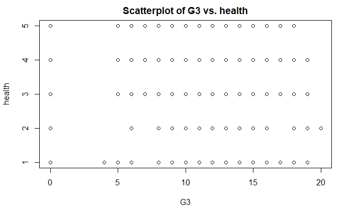

```r
plot(x = G3, y = health, main = "Scatterplot of G3 vs. health", xlab = "G3", ylab = "health")
```

```r
cor.test(G3, health)
```

```
    Pearson's product-moment correlation

data:  G3 and health
t = -1.2182, df = 393, p-value = 0.2239
alternative hypothesis: true correlation is not equal to 0
95 percent confidence interval:
 -0.15904311  0.03756376
sample estimates:
       cor
-0.0613346
```

There does not seem to be an association between health and G3.

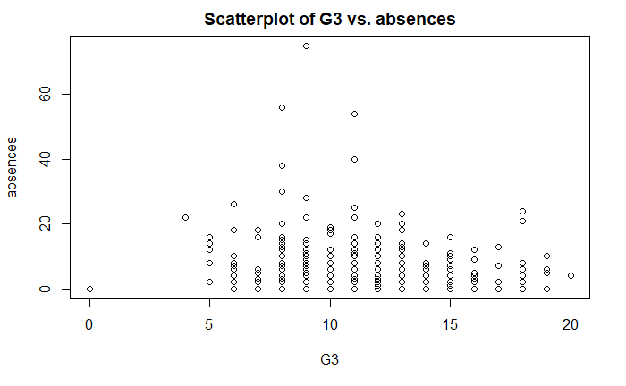

```r
plot(x = G3, y = absences, main = "Scatterplot of G3 vs. absences", xlab = "G3", ylab = "absences")
```

```r
cor.test(G3, absences)
```

```
    Pearson's product-moment correlation

data:  G3 and absences
t = 0.67933, df = 393, p-value = 0.4973
alternative hypothesis: true correlation is not equal to 0
95 percent confidence interval:
 -0.06464215  0.13247070
sample estimates:
       cor
0.03424732
```

There does not seem to be an association between absences and G3.

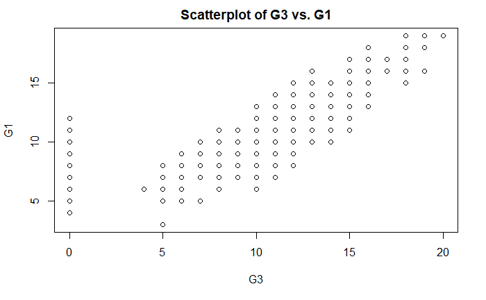

```r
plot(x = G3, y = G1, main = "Scatterplot of G3 vs. G1", xlab = "G3", ylab = "G1")
```

```r
cor.test(G3, G1)
```

```
    Pearson's product-moment correlation

data:  G3 and G1
t = 26.568, df = 393, p-value < 2.2e-16
alternative hypothesis: true correlation is not equal to 0
95 percent confidence interval:
 0.7631479 0.8341713
sample estimates:
      cor
0.8014679
```

There appears to be an association between G1 and G3.

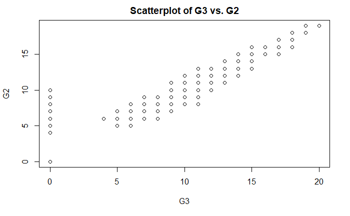

```r
plot(x = G3, y = G2, main = "Scatterplot of G3 vs. G2", xlab = "G3", ylab = "G2")
```

```r
cor.test(G3, G2)
```

```
    Pearson's product-moment correlation

data:  G3 and G2
t = 42.139, df = 393, p-value < 2.2e-16
alternative hypothesis: true correlation is not equal to 0
95 percent confidence interval:
 0.8852345 0.9212830
sample estimates:
     cor
0.904868
```

There appears to be an association between G2 and G3.

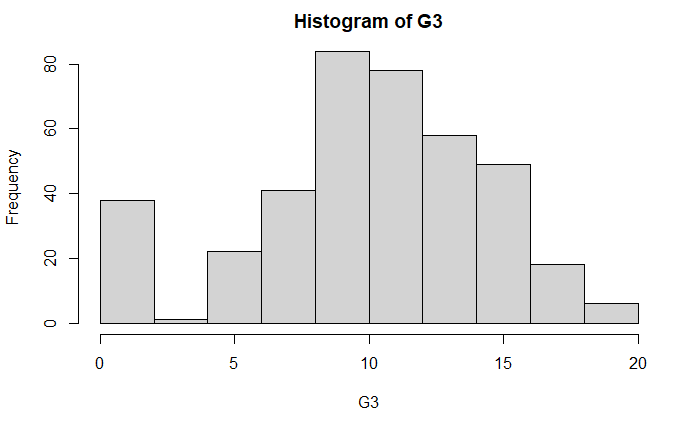

```r
hist(student$G3, main = "Histogram of G3", xlab = "G3")
```

```r
length(which(G3 > 8 & G3 < 11))
```

```
[1] 84
```

12. Split data to training (80%) and testing (20%)

```r
student_sample <- sample(395, 316)
student_train <- student[student_sample, ]
student_test <- student[-student_sample, ]
```

13. Set random seed: set.seed(123)

```r
set.seed(123)
```

14. use caret to run 10 fold cross validation using linear regression method on the train data set to predict “G3”. Print resulting model to see cross validation RMSE. Take a summary of the model and interpret coefficients.

```r
library(caret)
train.control = trainControl(method = "cv", number = 10)

student_model = train(G3~., data = student_train, method = "lm", trControl = train.control)
print(student_model)
```

```
Linear Regression

316 samples
 32 predictor

No pre-processing
Resampling: Cross-Validated (10 fold)
Summary of sample sizes: 284, 284, 284, 284, 284, 285, ...
Resampling results:

  RMSE      Rsquared   MAE
  2.008596  0.8149505  1.380745

Tuning parameter 'intercept' was held constant at a value of TRUE
```

```r
summary(student_model)
```

```
Call:
lm(formula = .outcome ~ ., data = dat)

Residuals:
    Min      1Q  Median      3Q     Max
-7.5393 -0.5990  0.2451  1.0387  3.8058

Coefficients:
                 Estimate Std. Error t value Pr(>|t|)
(Intercept)      -1.03771    2.43219  -0.427 0.669963
schoolMS          0.45016    0.39316   1.145 0.253216
sexM              0.02948    0.26374   0.112 0.911090
age              -0.17222    0.11499  -1.498 0.135378
addressU          0.01502    0.30698   0.049 0.961003
famsizeLE3        0.16692    0.25864   0.645 0.519227
PstatusT         -0.19275    0.37008  -0.521 0.602892
Medu              0.05329    0.16857   0.316 0.752139
Fedu             -0.17070    0.14434  -1.183 0.237981
Mjobhealth        0.21041    0.57040   0.369 0.712496
Mjobother         0.49915    0.39090   1.277 0.202700
Mjobservices      0.48330    0.42566   1.135 0.257199
Mjobteacher       0.39201    0.55627   0.705 0.481581
Fjobhealth        0.57694    0.75308   0.766 0.444271
Fjobother         0.05770    0.56644   0.102 0.918939
Fjobservices      0.07551    0.58311   0.130 0.897053
Fjobteacher       0.29717    0.71676   0.415 0.678762
reasonhome        0.13182    0.28866   0.457 0.648269
reasonother       0.71157    0.42551   1.672 0.095612 .
reasonreputation  0.20500    0.29874   0.686 0.493168
guardianmother    0.35696    0.27814   1.283 0.200442
guardianother     0.67251    0.53743   1.251 0.211876
traveltime        0.08186    0.18167   0.451 0.652629
studytime        -0.25686    0.15399  -1.668 0.096454 .
failures         -0.29043    0.18249  -1.591 0.112660
schoolsupyes      0.81599    0.37486   2.177 0.030351 *
famsupyes         0.10628    0.24885   0.427 0.669660
paidyes           0.15818    0.24744   0.639 0.523198
activitiesyes    -0.30918    0.23148  -1.336 0.182770
nurseryyes       -0.64904    0.30125  -2.154 0.032076 *
higheryes         0.16797    0.60726   0.277 0.782297
internetyes      -0.30640    0.32918  -0.931 0.352776
romanticyes      -0.32817    0.25909  -1.267 0.206362
famrel            0.39510    0.12585   3.139 0.001878 **
freetime         -0.07012    0.12336  -0.568 0.570210
goout             0.10665    0.11950   0.892 0.372941
Dalc             -0.21571    0.19017  -1.134 0.257659
Walc              0.11354    0.13757   0.825 0.409880
health            0.14210    0.08399   1.692 0.091826 .
absences          0.06612    0.01810   3.652 0.000312 ***
G1                0.19045    0.07318   2.603 0.009755 **
G2                0.96462    0.06303  15.303  < 2e-16 ***
---
Signif. codes:  0 ‘***’ 0.001 ‘**’ 0.01 ‘*’ 0.05 ‘.’ 0.1 ‘ ’ 1

Residual standard error: 1.896 on 274 degrees of freedom
Multiple R-squared:  0.8579,    Adjusted R-squared:  0.8366
F-statistic: 40.34 on 41 and 274 DF,  p-value: < 2.2e-16
```

```r
predict_student_test <- predict(student_model,student_test)

RMSE_student_test <- sqrt(mean((student_test$G3- predict_student_test)^2))
RMSE_student_test
```

```
[1] 2.195668
```

Set random seed again

16. Use caret/leap to run 10 fold cross validation with stepwise linear regresssion with backward selection on the train data.

```r
library(leaps)
library(caret)
set.seed(123)
step_train.control = trainControl(method = "cv", number = 10)
step.model <- train(G3~., data = student_train, method = "leapBackward", trControl = step_train.control, tuneGrid = data.frame(nvmax = 2:32))

print(step.model)
```

```
Linear Regression with Backwards Selection

316 samples
 32 predictor

No pre-processing
Resampling: Cross-Validated (10 fold)
Summary of sample sizes: 284, 284, 284, 284, 284, 285, ...
Resampling results across tuning parameters:

  nvmax  RMSE      Rsquared   MAE
   2     1.951807  0.8219592  1.166274
   3     1.895585  0.8322027  1.173766
   4     1.946853  0.8234685  1.215249
   5     1.952583  0.8224352  1.249836
```

[output cut: 30 more lines]

```r
summary(step.model$finalModel)
```

```
Subset selection object
41 Variables  (and intercept)
                 Forced in Forced out
schoolMS             FALSE      FALSE
sexM                 FALSE      FALSE
age                  FALSE      FALSE
addressU             FALSE      FALSE
famsizeLE3           FALSE      FALSE
PstatusT             FALSE      FALSE
Medu                 FALSE      FALSE
Fedu                 FALSE      FALSE
Mjobhealth           FALSE      FALSE
Mjobother            FALSE      FALSE
Mjobservices         FALSE      FALSE
Mjobteacher          FALSE      FALSE
Fjobhealth           FALSE      FALSE
Fjobother            FALSE      FALSE
Fjobservices         FALSE      FALSE
Fjobteacher          FALSE      FALSE
reasonhome           FALSE      FALSE
reasonother          FALSE      FALSE
reasonreputation     FALSE      FALSE
guardianmother       FALSE      FALSE
guardianother        FALSE      FALSE
traveltime           FALSE      FALSE
studytime            FALSE      FALSE
failures             FALSE      FALSE
schoolsupyes         FALSE      FALSE
famsupyes            FALSE      FALSE
paidyes              FALSE      FALSE
activitiesyes        FALSE      FALSE
nurseryyes           FALSE      FALSE
higheryes            FALSE      FALSE
internetyes          FALSE      FALSE
romanticyes          FALSE      FALSE
famrel               FALSE      FALSE
freetime             FALSE      FALSE
goout                FALSE      FALSE
Dalc                 FALSE      FALSE
Walc                 FALSE      FALSE
health               FALSE      FALSE
absences             FALSE      FALSE
G1                   FALSE      FALSE
G2                   FALSE      FALSE
1 subsets of each size up to 3
Selection Algorithm: backward
         schoolMS sexM age addressU famsizeLE3 PstatusT Medu Fedu Mjobhealth Mjobother Mjobservices Mjobteacher Fjobhealth Fjobother Fjobservices Fjobteacher reasonhome reasonother reasonreputation guardianmother
1  ( 1 ) " "      " "  " " " "      " "        " "      " "  " "  " "        " "       " "          " "         " "        " "       " "          " "         " "        " "         " "              " "
2  ( 1 ) " "      " "  " " " "      " "        " "      " "  " "  " "        " "       " "          " "         " "        " "       " "          " "         " "        " "         " "              " "
3  ( 1 ) " "      " "  " " " "      " "        " "      " "  " "  " "        " "       " "          " "         " "        " "       " "          " "         " "        " "         " "              " "
         guardianother traveltime studytime failures schoolsupyes famsupyes paidyes activitiesyes nurseryyes higheryes internetyes romanticyes famrel freetime goout Dalc Walc health absences G1  G2
1  ( 1 ) " "           " "        " "       " "      " "          " "       " "     " "           " "        " "       " "         " "         " "    " "      " "   " "  " "  " "    " "      " " "*"
2  ( 1 ) " "           " "        " "       " "      " "          " "       " "     " "           " "        " "       " "         " "         " "    " "      " "   " "  " "  " "    "*"      " " "*"
3  ( 1 ) " "           " "        " "       " "      " "          " "       " "     " "           " "        " "       " "         " "         "*"    " "      " "   " "  " "  " "    "*"      " " "*"
```

The model with nvmax = 3 has the lowest cross validation RMSE.

Variables famrel, absences, and G2 are selected in the model.

17. Compute RMSE of stepwise model of the test data

```r
predict_step_student_test <- predict(step.model,student_test)

RMSE_step_student_test <- sqrt(mean((student_test$G3- predict_step_student_test)^2))
RMSE_step_student_test
```

```
[1] 1.890592
```

18. Use “rpart” function to create a regression tree model from the train data. Get predictions on test data and compute RMSE.

```r
library(rpart)
train.rpart <- rpart(G3~., data = student_train)

predict_rpart <- predict(train.rpart, student_test)

RMSE_rpart_student_test <- sqrt(mean((student_test$G3- predict_rpart)^2))
RMSE_rpart_student_test
```

```
[1] 2.090254
```

19. Compare the RMSE on the test data for linear, stepwise, and the regression tree.

RMSE of linear regression : 2.20

RMSE of stepwise regression: 1.89

RMSE of regression tree: 2.09

Based on these values, the stepwise regression model appears to be better at predicting students’ final grade in math.